# Recent Financial Cycles- Statistical Features and Parameters

Leonardo Zepeda

20 Ene 2022

## Abstract

With the latest, and considering only statistical features, we could infer current cycle still have between 294 and 587 days left with the expectation to deliver at least 1.58 times its initial values, from which DOW has ran 91% of it already, and S&P has surpassed 2% above its peak already. The analysis also infers that negative returns will be the norm on a weekly and monthly basis and by now, this cycle present already more negative incidences than cycle’s average, and also that that there is not a noticeable trend for immediate recovery after sensitive falls. However, at the end of the cycle, positive shots will compensate incidental losses.

[Code is available here](https://github.com/leonardozg/Macro-and-Markets/blob/master/V%20Shape2.Rmd)

## The Data

The data comes from Yahoo Finance, selecting the adjusted price column. These data correct the irregularities generated by idiosyncratic events of the firms that are not market movements (dividends, splits, etc.). Thus, the data are comparable over time. From them we create new columns: returns (daily percentage change), lagged price and lagged performance. Lagging performance is simply the performance of the previous day.

Our objective is to find out critical statistical features to describe a cycle: length, weekly returns, monthly returns, total returns per cycle, and other technical (statistical) features and parameters useful for risk management.

## A First Visual Analysis

By observing historical levels we notice dramatic changes against certain dramatic events. More relevant and dramatic are 1987 crisis, 9/11 in 2001 and the sub-prime crisis in 2009 and more recently the dramatic COVID-19 crisis in 2020. Is also noticeable that indexes behave highly correlated over time.

### Graph I -Levels

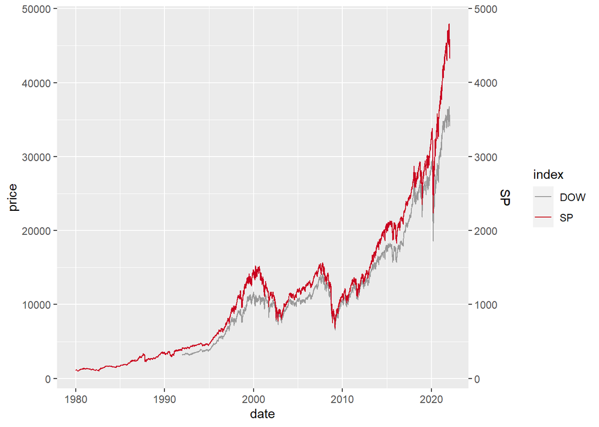

### Leveling Perspective

Price’s magnitude distract the observer from the size of the variations. By considering price levels of 2020 (around 30,000 points for DOW) the observer may perceive a reduced importance of price variations in say, 1987 (when prices of DOW were one-tenth of 2020 levels). By using returns we can focus in the magnitude of the change avoiding the distraction of increasing price levels. In order to filter only “sustained” variations, used returns are on weekly and monthly basis

### Graph II -Returns

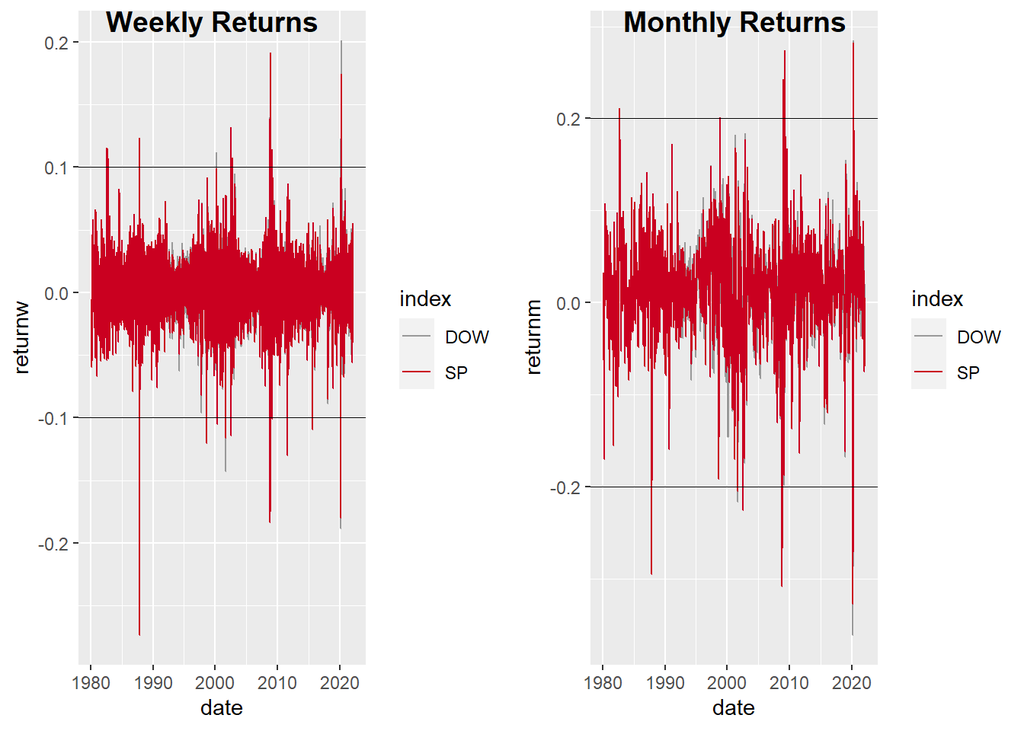

## Is there a trend for sudden recovery ?

One of the interesting aspects to analyze is to find out if there is a noticeable trend for recovery after sensitive falls. First we will analyze global patterns of recovery by plotting returns against lagged returns in weekly (7 days) and monthly basis (30 days). If immediate or abrupt recovery was a pattern, we should expect a more dense cloud of points in the higher-left corner of the graph, meaning that sensitive falls corresponds to sensitive recovery. As observed in following graph neither for DJI or S&P 500 and weekly nor monthly data suggest that it would be the case.

### Graph III -Recovery Paterns

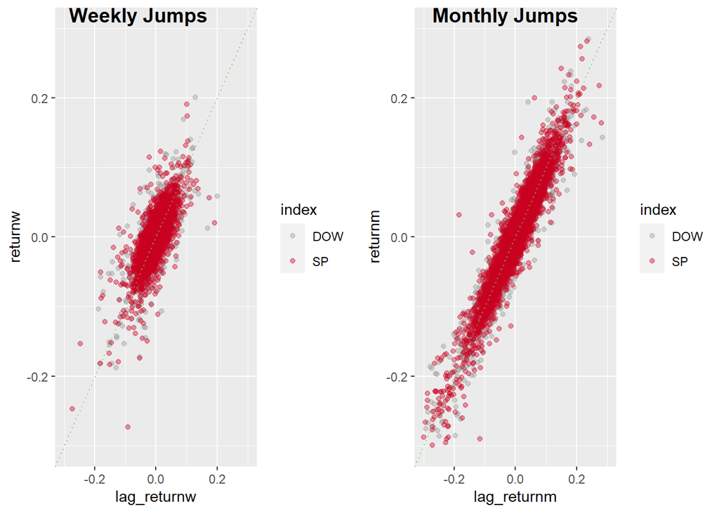

To validate the latest inference, we arrange data in “equally-sized volatility clusters” regardless of the time of occurrence. We arrange data in 100 equally sized groups. We call them Similar Volatility Groups. As a result from that arrangement, the first group will contain 1% of the smallest lagged returns, while the latest group will contain the 1% largest lagged returns. Then for each group we calculate its mean and the positive portion of each group.

By filtering only current positive returns, we observe that the groups with the smallest returns correspond to negative mean lagged returns and the largest returns correspond to the largest positive lagged mean returns in asymptotycal line around the 0 mean. The latest complies for both weekly and monthly lagged returns. Up to now it might be confirmed that there is not a noticeable trend for recovery after sensitive falls.

Moreover, when plotting its density we find that there is sensitively more density of positive cases, within the 50% larger lagged returns. This may imply that the magnitude of the recovery is more often related with previous positive returns, than with sensitive falls. A momentum argument as commonly referred by traders.

## Graph IV -Recovery Paterns in depth

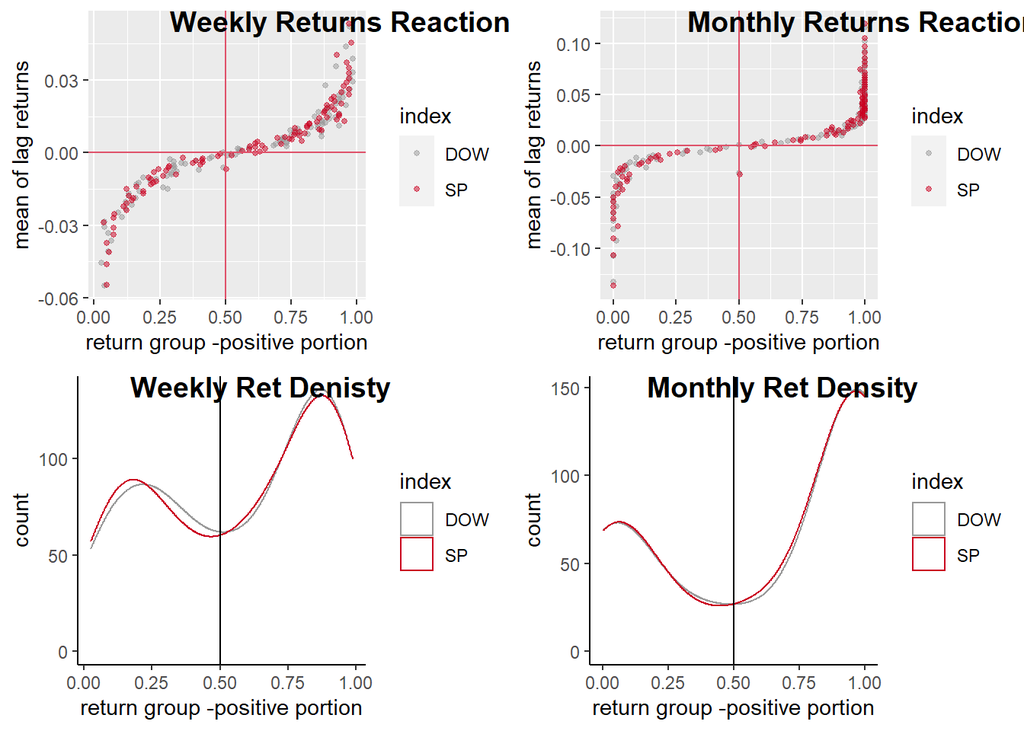

## Features of cyles

There are several methods and criteria to identify cycles. Far from any theoretical stance and with a mere practical objective, in this analysis we define the start of a cycle with a threshold of a 10% or bigger daily fall, coincident with a 10% weekly and a 10% monthly fall in index prices. As arbitrary as it seems, it provides 7 coincident falls (for both indexes) from 1985 to 2021 (see Graph 2 and 3)

### Critical dates

| Date | Index |
| --- | --- |
| 1987/10/19 | DOW, S&P |
| 1998/08/31 | DOW, S&P |
| 2001/09/17 | DOW, S&P |
| 2002/07/22 | S&P |
| 2008/10/07 | DOW, S&P |
| 2009/02/23 | S&P |
| 2011/08/08 | DOW, S&P |
| 2015/08/25 | DOW, S&P |
| 2020/02/27 | DOW, S&P |
| ———- | ———- |

To identify a cycle we consider only critical dates coincident for both indexes what excludes: 2002/07/22 and 2009/02/23 from the S&P index.

### Length of Cycles

Cycle length is calculated by the number of days between one 10%+ (daily, weekly and monthly) coincident fall and the next one in occurrence. Length cycle is represented in Graph V. Please note that since the start date of series is arbitrary, cycle one for both index are not consistent. Also please note that cycle 7 is at early stage.

### Graph V -Length of Cycles

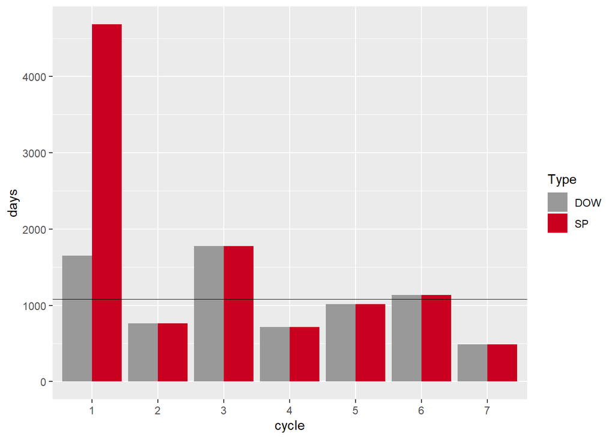

### Graph VI -Potential Return of Cycles

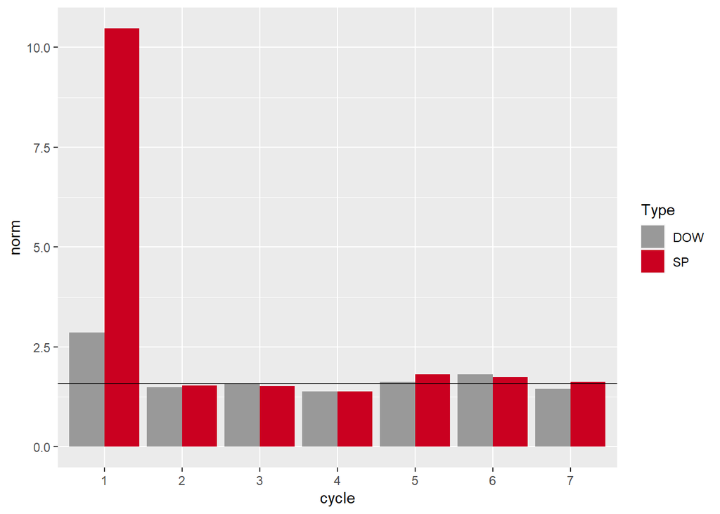

### Graph VII -Cycles

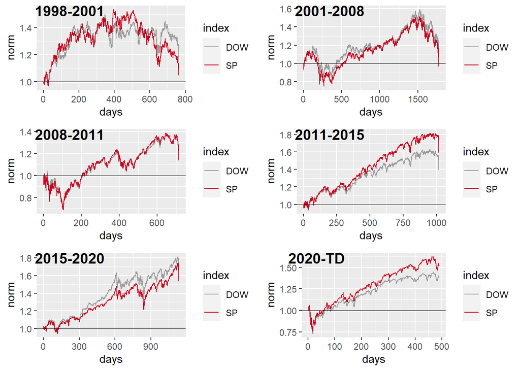

### Weekly Returns -Descriptive statistics per cycle

Besides length of the cycle, central tendency analysis may reveal another important features. Every cycle present different weekly features regarding mean returns, volatility (standard deviation), skewness, and kurtosis. All this features are represented in the following graphs and tables.

### Graph VIII -Weekly Returns -Distribution of returns

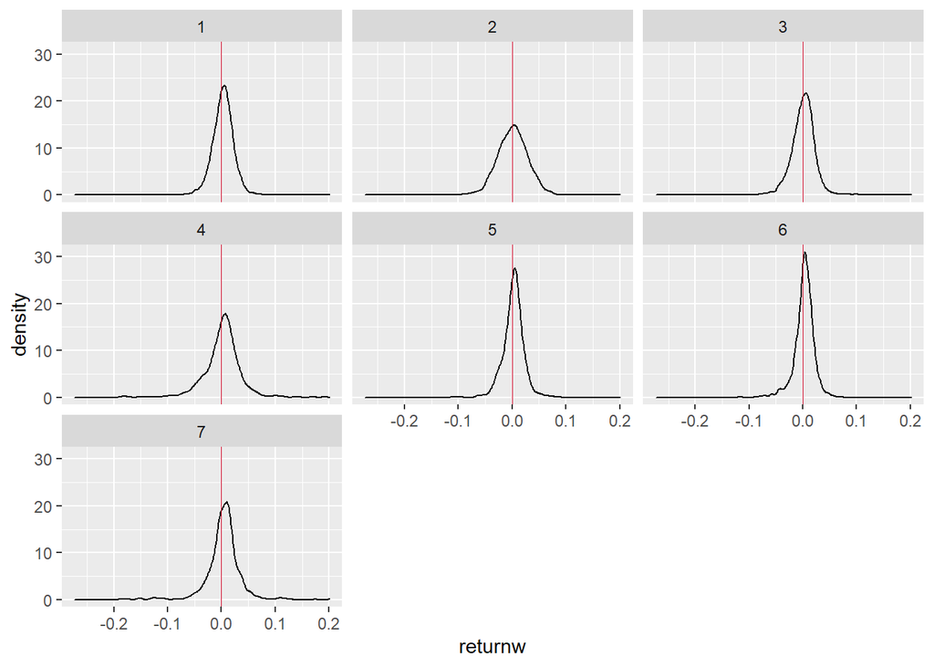

Remembering statistics: if the skewness is between -0.5 and 0.5, the data are fairly symmetrical. If the skewness is between -1 and – 0.5 or between 0.5 and 1, the data are moderately skewed. If the skewness is less than -1 or greater than 1, the data are highly skewed.Negative values for the skewness indicate data that are skewed left and positive values for the skewness indicate data that are skewed right. By skewed left, we mean that the left tail (negative returns incidence) is long relative to the right tail (positive returns incidence). A positive mean with a negative skew, means negative incidence but not enough to deliver a negative mean, in other words, fewer cases are highly positive. In terms of kurtosis, what we should consider is how the incidence falls far from 0. When kurtosis is above 1, we may conclude most incidence falls near 0, but far from normal shape distribution.

DOW Cycles Weekly statistical features

| days | mean(bp) | sd | skewness | kurosis |
| --- | --- | --- | --- | --- |
| 1648 | 29.41352 | 0.0173122 | -0.6107945 | 2.8320741 |
| 764 | 14.14445 | 0.0268605 | -0.0701918 | 0.6651342 |
| 1777 | 4.29654 | 0.0226467 | -0.3338475 | 4.7871631 |
| 714 | 13.55298 | 0.0323004 | -0.6031292 | 5.5733275 |
| 1018 | 19.49517 | 0.0187700 | -0.4516548 | 3.2169428 |
| 1134 | 24.12576 | 0.0185049 | -1.0013622 | 4.0584951 |
| 490 | 31.85318 | 0.0336938 | -0.7939943 | 9.6249990 |

S&P Cycles Weekly statistical features

| days | mean(bp) | sd | skewness | kurosis |
| --- | --- | --- | --- | --- |
| 4682 | 25.836978 | 0.0214184 | -1.0254654 | 12.5178094 |
| 764 | 7.196581 | 0.0285053 | -0.0683870 | 0.2822286 |
| 1777 | 2.434895 | 0.0227557 | -0.3101766 | 4.1413968 |
| 714 | 13.845379 | 0.0355070 | -0.5846155 | 5.0250587 |
| 1018 | 26.095323 | 0.0199758 | -0.4669984 | 3.6606779 |
| 1134 | 22.513281 | 0.0181972 | -1.0879144 | 4.2767242 |
| 490 | 41.805412 | 0.0311217 | -0.8852396 | 8.0575733 |

### Monthly Returns -Descriptive statistics per cycle,

Besides length of the cycle, central tendency analysis may reveal another important features. Every cycle present different monthly features regarding mean returns, its volatility (standard deviation), its skewness, and kurtosis. All this features are represented in the following graph and tables.

### Graph IX -Distribution of returns

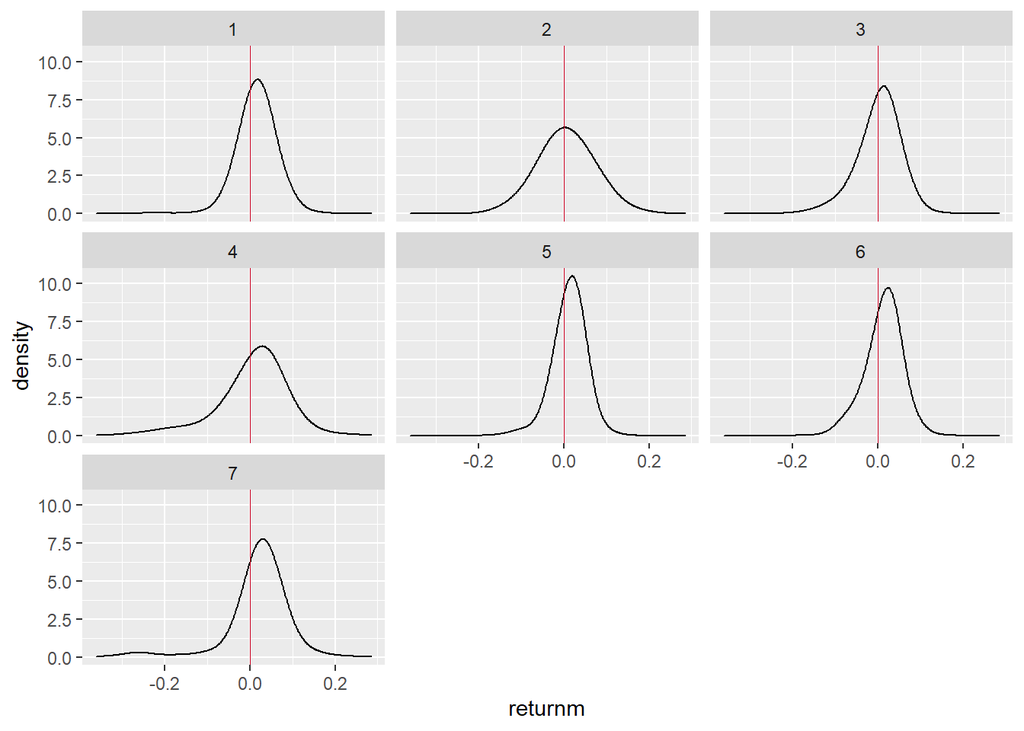

DOW Cycles Monthly statistical features

| days | mean(bp) | sd | skewness | kurosis |
| --- | --- | --- | --- | --- |
| 1648 | 186.40461 | 0.0374510 | -0.1262172 | 0.7131017 |
| 764 | 84.43536 | 0.0618898 | 0.0411795 | 0.0298988 |
| 1777 | 25.95773 | 0.0500465 | -0.7075157 | 1.3842516 |
| 714 | 75.00987 | 0.0741046 | -0.9942326 | 1.8947280 |
| 1018 | 110.66126 | 0.0361364 | -0.6245191 | 1.7710250 |
| 1134 | 142.16087 | 0.0423092 | -0.4828789 | 0.6535559 |
| 490 | 163.48616 | 0.0765182 | -1.8965216 | 6.9541425 |

S&P Cycles Monthly statistical features

| days | mean(bp) | sd | skewness | kurosis |
| --- | --- | --- | --- | --- |
| 4682 | 158.33327 | 0.0496389 | -0.7231017 | 3.9134350 |
| 764 | 42.83200 | 0.0615426 | 0.0827184 | 0.1679607 |
| 1777 | 18.64870 | 0.0503776 | -0.7763416 | 1.4838870 |
| 714 | 68.92202 | 0.0822561 | -0.9564228 | 2.1679159 |
| 1018 | 146.53337 | 0.0385787 | -0.8213659 | 2.1379069 |
| 1134 | 130.80032 | 0.0402066 | -0.6520906 | 0.9764067 |
| 490 | 236.87314 | 0.0735267 | -1.7784054 | 6.3268817 |

### Negative Incidence

As described in the previous section we must expect negative skew which means more negative hits (compared with its initial level) in both weekly and monthly returns. With that in mind we try to find negative patterns.

The following graph shows the number of days with negative returns and the portion those represent of the length cycle.

For the graph on the left, the horizontal lines are the cycles’ average negative days for DOW (89.28 days) and S&P (118.14 days). Current cycle has had 59 and 52 negative days for DOW and S&P respectively, which means we could expect at least another 30 and 66 negative days respectively.

### Graph X -Negative Incidence

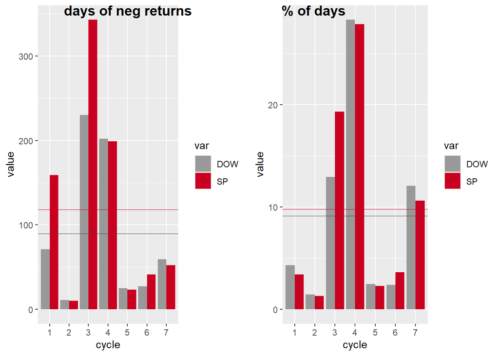

### Conclusion

The analysis found that a cycle’s length range from 714 to 1,777 days, averaging 20 basis points (bp) and 113 bp weekly and monthly returns respectively for DOW index; and 20 bp and 114 bp weekly and monthly returns respectively for S&P index. The analysis also found that cycle’s total returns averaged 1.58 and 1.59 times it initial values for DOW and S&P indexes respectively, ranging from 1.38 to 1.81 times for both indexes.

With the latest, and considering only statistical features, we could infer current cycle still have between 294 and 587 days left with the expectation to deliver at least 1.58 times its initial values, from which DOW has ran 91% of it already, and S&P has surpassed 2% above its peak already. The analysis also infers that negative returns will be the norm on a weekly and monthly basis and by now, this cycle present already more negative incidences than cycle’s average, and also that that there is not a noticeable trend for immediate recovery after sensitive falls. However, at the end of the cycle, positive shots will compensate incidental losses.